# Logic Converter

2.2.4 Design Tool  
Truth table to logic circuit

One function.  
AOI and NAND implementations.

Conner Glover  
Digital Electronics · Period F · Unit 2

Conceptual logic map · not a recorded circuit

## The three-input expression becomes A'B + BC'.

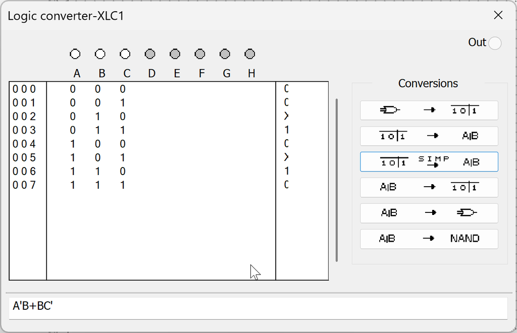

### Before simplification

A'BC + ABC'

### After simplification

A'B + BC'

Apostrophe = NOT.  
Adjacent letters = AND.  
Plus = OR.

Original expression detail · cir1.png

## The simplification preserves every required output.

| ABC | Required | A'BC + ABC' | A'B + BC' |
| --- | --- | --- | --- |
| 000 | 0 | 0 | 0 |
| 001 | 0 | 0 | 0 |
| 010 | X | 0 | 1 |
| 011 | 1 | 1 | 1 |
| 100 | 0 | 0 | 0 |
| 101 | X | 0 | 0 |
| 110 | 1 | 1 | 1 |
| 111 | 0 | 0 | 0 |

6 / 6

Specified rows agree.

X = don't-care.  
At 010, the output can change from 0 to 1.

At 101, both forms give 0.

Calculated check.  
Not a simulation test log.

## Majority Vote reduces to four product terms.

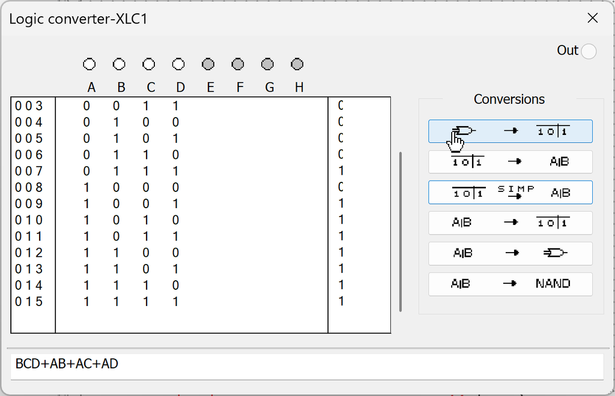

### Variable mapping

A B C D  
P V S T

Vote =  
VST + PV  
+ PS + PT

Calculated equivalence:  
16 of 16 rows match.

HIGH minterms:  
7, 9, 10, 11,  
12, 13, 14, 15.

## The recording contains the Majority Vote AOI circuit.

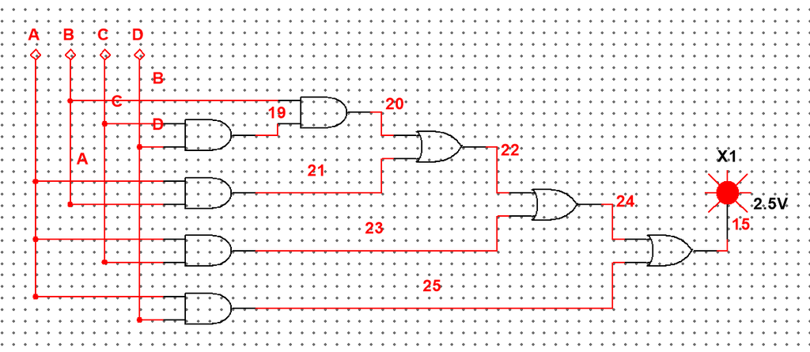

demo.gif · frame 85 detail. AND paths feed an OR chain. A–D remain the displayed input labels.

## The recording also contains a NAND-only circuit.

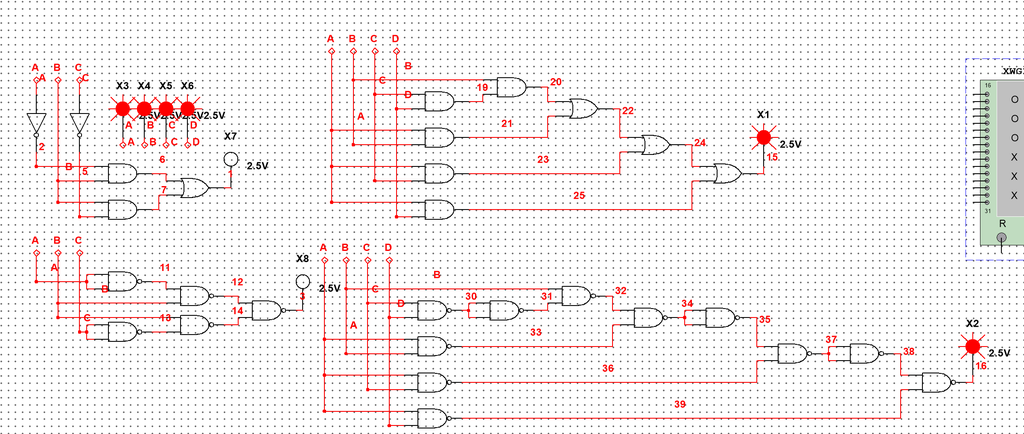

Outlined: Majority Vote NAND implementation. Upper-right: AOI. Left: the three-input example.

## Both circuits agree in two recorded states.

ABCD = 0000 · frame 7

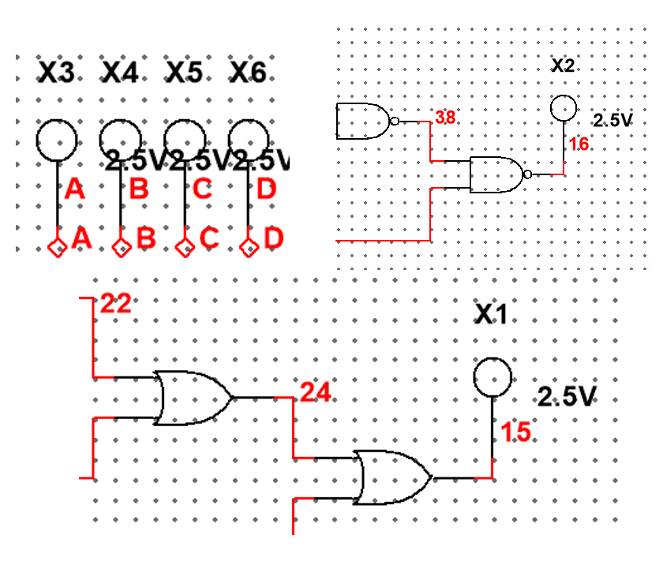

Inputs A–DNAND · X2 LOWAOI · X1 LOW

ABCD = 1111 · frame 85

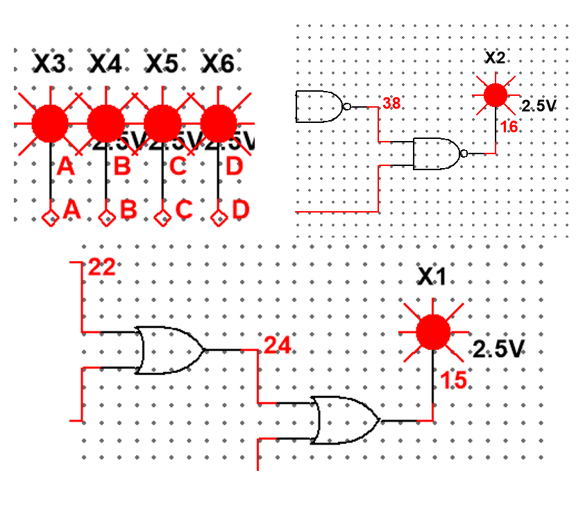

Inputs A–DNAND · X2 HIGHAOI · X1 HIGH

Genuine detail crops. These examples do not establish a complete 16-state simulation test.